# Homework

### 11.5

Write a function to solve the equation
$$\begin{equation}
\begin{gathered}
\frac{2 \Gamma\left(\frac{k}{2}\right)}{\sqrt{\pi(k-1)} \Gamma\left(\frac{k-1}{2}\right)} \int_{0}^{c_{k-1}}\left(1+\frac{u^{2}}{k-1}\right)^{-k / 2} d u \\
=\frac{2 \Gamma\left(\frac{k+1}{2}\right)}{\sqrt{\pi k} \Gamma\left(\frac{k}{2}\right)} \int_{0}^{c_{k}}\left(1+\frac{u^{2}}{k}\right)^{-(k+1) / 2} d u
\end{gathered}
\end{equation}$$

for a, where
$$c_k=\sqrt{\frac{a^2k}{k+1-a^2}}$$

Compare the solutions with the points A(k) in Exercise 11.4.

解：

$\because$由题可知，

```r
ck<-function(a,k){
  return(sqrt(a^2*k/(k+1-a^2)))
}
solve<-function(a){
  nu<-1/2*log(k)+2*lgamma(k/2)+log(integrate(function(u){(1+u^2/(k-1))^(-k/2)},0,ck(a,k-1))$value)
  de<-1/2*log(k-1)+lgamma((k-1)/2)+lgamma((k+1)/2)+
    log(integrate(function(u){(1+u^2/k)^(-(k+1)/2)},0,ck(a,k))$value)
  return(nu-de)
}
```

不妨设a>0，那么我们有：

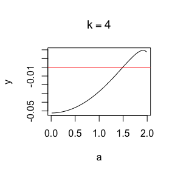

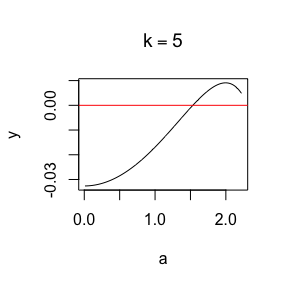

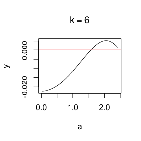

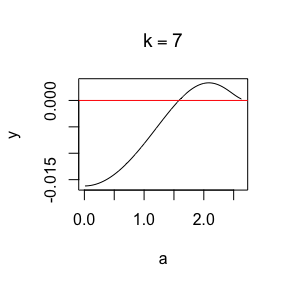

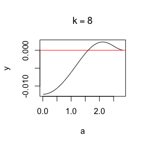

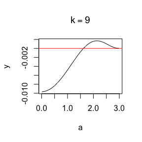

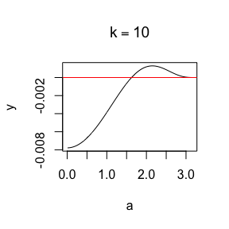

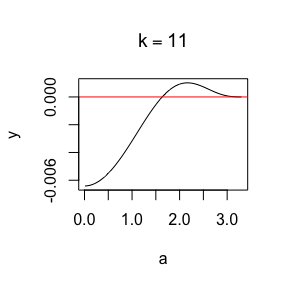

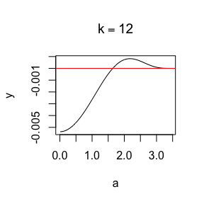

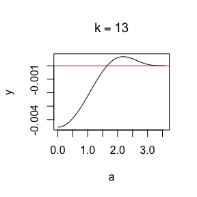

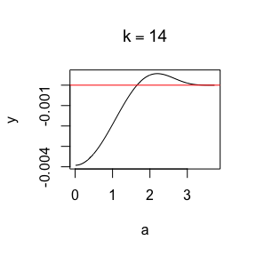

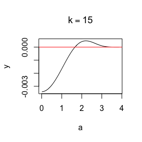

[13 more figures not shown]

```r
m<-c(4:25,100,500,1000)
solution<-numeric(length(m))
for(i in 1:length(m)){
  k<-m[i]
  if(k<=25){
    a<-seq(0.01,sqrt(k)-0.01,0.01)
  }
  if(k>25){
    a<-seq(0.01,4,0.01)
  }
  y<-numeric(length(a))
  for(j in 1:length(a)){
    y[j]<-solve(a[j])
  }
  plot(a,y,type="l",main=bquote(k==.(m[i])))
  abline(h=0,col="red")
}
```

由于k=100，500，1000时sqrt(k)太大了，导致图像就是一条横线，所以对于此时的k我们另外选择a的取值范围。通过上面的图我们发现解基本在（1，2）之间，所以用uniroot函数解方程即可得到a，下面是函数实现：

```r
for(i in 1:length(m)){
  k<-m[i]
  solution[i]<-uniroot(function(a){solve(a)},lower=1,upper=2)$root
}
round(solution,4)
```

```
##  [1] 1.4921 1.5336 1.5627 1.5844 1.6012 1.6145 1.6254 1.6344 1.6420 1.6485
## [11] 1.6542 1.6591 1.6634 1.6673 1.6707 1.6738 1.6766 1.6792 1.6815 1.6836
## [21] 1.6855 1.6873 1.7206 1.7297 1.7309
```

对于Exercise 11.4

```r
solve2<-function(k){
  value<-uniroot(function(a){pt(ck(a,k),df=k)-pt(ck(a,k-1),df=k-1)},lower=1,upper=2)
  value$root
}
for(i in 1:length(m)){
  k<-m[i]
  solution[i]<-solve2(k)
}
round(solution,4)
```

```
##  [1] 1.4921 1.5336 1.5627 1.5844 1.6012 1.6145 1.6254 1.6344 1.6420 1.6486
## [11] 1.6542 1.6591 1.6635 1.6673 1.6707 1.6738 1.6766 1.6792 1.6815 1.6836
## [21] 1.6856 1.6874 1.7206 1.7298 1.7309
```

发现与11.4的结果基本相同。

### Homework

Suppose $T_1, \dots, T_n$ are i.i.d. samples drawn from the exponential distribution with expectation $\lambda$. Those values greater than $\tau$ are not observed due to right censorship, so that the observed values are $Y_i = T_iI(T_i ≤ \tau) + \tau I(T_i > \tau)$, $i = 1,\dots,n$. Suppose $\tau$ = 1 and the observed $Y_i$ values are as follows:

```
0.54, 0.48, 0.33, 0.43, 1.00, 1.00, 0.91, 1.00, 0.21, 0.85
```

Use the E-M algorithm to estimate $\lambda$, compare your result with the observed data MLE (note: $Y_i$ follows a mixture distribution).

解：

$\because$由题可知真实数据为$Y=(Y_1,\dots,Y_{10})$，完全数据为$(Y_1,Y_2,Y_3,Y_4,T_5,T_6,Y_7,T_8,Y_9,Y_{10})$，我们不妨重新排序为$Y'=(X_1,\dots,X_{10})$，此时的$T_1,T_2,T_3$表示的是上面的$T_5,T_6,T_8$，所以此时的似然函数可以写为：
$$L(\lambda\mid Y')=(\frac{1}{\lambda})^{10}e^{-\frac{1}{\lambda}(\sum_{i=1}^{10}X_i)},\quad Y_i\leq1,T_i>1$$

所以对数似然函数可以写为：
$$l(\lambda\mid Y')=-\frac{1}{\lambda}(\sum_{i=1}^{10}X_i)-10ln\lambda$$

所以由EM算法可知，此时E步为：
$$Q(\lambda,\hat{\lambda}^{(i)})=E\{-\frac{1}{\lambda}(\sum_{i=1}^{10}X_i)-10ln\lambda\mid Y_1,\dots,Y_{10}, \hat{\lambda}^{(i)}\}$$
$$\Rightarrow =-\frac{1}{\lambda}E\{T_5+T_6+T_8 \mid Y_1,\dots,Y_{10}, \hat{\lambda}^{(i)}\}-\frac{1}{\lambda}(Y_1+\dots+Y_4+Y_7+Y_9+Y_{10})-10ln\lambda$$

又此时算$T_5\mid Y_1,\dots,Y_{10},\hat{\lambda}^{(i)}=T_5\mid Y_5,\hat{\lambda}^{(i)}$的分布

$$P(T_5\mid Y_5,\hat{\lambda}^{(i)})=P(T_5,Y_5\mid \hat{\lambda}^{(i)})/P(Y_5\mid \hat{\lambda}^{(i)})=\int_1^t\frac{1}{\lambda}e^{-\frac{1}{\lambda}x}dx/\int_1^{\infty}\frac{1}{\lambda}e^{-\frac{1}{\lambda}x}dx$$
$$\Rightarrow =1-e^{-\frac{1}{\hat{\lambda}^{(i)}}(t-1)},\quad t>1$$

所以此时密度为
$$f(t)=\frac{1}{\hat{\lambda}^{(i)}}e^{-\frac{1}{\hat{\lambda}^{(i)}}(t-1)},t>1$$

所以此时的期望为$\hat{\lambda}^{(i)}+1$，代回E步

$$Q(\lambda,\hat{\lambda}^{(i)})=-\frac{3}{\lambda}(\hat{\lambda}^{(i)}+1)-\frac{1}{\lambda}(Y_1+\dots+Y_4+Y_7+Y_9+Y_{10})-10ln\lambda$$

再进行M步关于$\lambda$求导数

$$\frac{3}{\lambda^2}(\hat{\lambda}^{(i)}+1)+\frac{1}{\lambda^2}(Y_1+\dots+Y_4+Y_7+Y_9+Y_{10})-\frac{10}{\lambda}=0$$
$$\Rightarrow \hat{\lambda}^{(i+1)}=\frac{3(\hat{\lambda}^{(i)}+1)+(Y_1+\dots+Y_4+Y_7+Y_9+Y_{10})}{10}$$

所以下面进行编程来进行实现

```r
Y<-c(0.54, 0.48, 0.33, 0.43, 1.00, 1.00, 0.91, 1.00, 0.21, 0.85)
lambda<-0.375# initial
N<-10000
L<-numeric(N)
L[1]<-lambda
for(i in 2:N){
  L[i]<-(3*L[i-1]+sum(Y))/10 # for the value of 3+Y_1+\dots+Y_4+Y_7+Y_9+Y_{10} equals to sum(Y)
  if(abs(L[i]-L[i-1])<=0.0000001){
    print(L[i])
    break
  }
}
```

```
## [1] 0.9642857
```

再计算此时的MLE，由于此时是一部分连续一部分离散的，所以似然函数为

$$L(\lambda\mid Y)= f(Y_1)\cdots f(Y_4)\cdot f(Y_7)\cdot f(Y_9)\cdot f(Y_{10})\cdot P(Y_5)\cdot P(Y_6)\cdot P(Y_8)$$

所以对数似然为

$$l(\lambda\mid Y)=\frac{1}{\lambda}(Y_1+\cdots+Y_4+Y_7+Y_9+Y_{10})-\frac{3}{\lambda}-7ln\lambda$$

所以通过MLE方法计算得到此时的$\lambda^{ML}=(Y_1+\cdots+Y_4+Y_7+Y_9+Y_{10}+3)/7=0.9642857$

所以综合来看可以发现两者的值相同，即EM算法的值与MLE算出的结果在此条件下基本相同。

# A-21038-2021-11-25

## Question

- P204.1 Why are the following two invocations of lapply() equivalent

```
trims<-c(0,0.1,0.2,0.5)
x<-rcauchy(100)

lapply(trims, function(trim) mean(x,trim=trim))
lapply(trims, mean, x=x)
```

- P204.5 For each model in the previous two exercises, extract $R^2$ using the function below.

```
rsq<-function(mod) summary(mod)$r.squared
```

- P214.1 Use vapply() to:
1. Compute the standard deviation of every column in a numeric data frame.
2. Compute the stamdard deviation of every numeric column in a mixed data frame. (Hint: you’ll need to use vapply() twice.)
- P214.7 Implement mcsapply(), a multicore version of sapply(). Can you implement mcvapply(), a parallel version of vapply()? Why or why not?

## Answer

### P204.1

Why are the following two invocations of lapply() equivalent

```
trims<-c(0,0.1,0.2,0.5)
x<-rcauchy(100)

lapply(trims, function(trim) mean(x,trim=trim))
lapply(trims, mean, x=x)
```

解：

$\because$由题可知，对于第一个方法，这是标准的运用lapply()，主要是第二个，此时我们可以通过查看mean()的参数知道，在运行过程中，由于mean函数的第一个参数x给定，所以自动将trims里的值赋给第二个参数trim，所以两个运算本质上是一样的，当然结果也一样。

```r
set.seed(0)
trims<-c(0,0.1,0.2,0.5)
x<-rcauchy(100)

lapply(trims, function(trim) mean(x,trim=trim))
```

```
## [[1]]
## [1] 2.614189
##
## [[2]]
## [1] 0.3893497
##
## [[3]]
## [1] 0.2359156
##
## [[4]]
## [1] 0.1303608
```

```r
lapply(trims, mean, x=x)
```

```
## [[1]]
## [1] 2.614189
##
## [[2]]
## [1] 0.3893497
##
## [[3]]
## [1] 0.2359156
##
## [[4]]
## [1] 0.1303608
```

### P204.5

For each model in the previous two exercises, extract $R^2$ using the function below.

```
rsq<-function(mod) summary(mod)$r.squared
```

解：

$\because$由题可知，可以通过代码依次实现：

```r
attach(mtcars)
rsq<-function(mod) summary(mod)$r.squared
formulas<-list(
  mpg ~ disp,
  mpg ~ I(1/disp),
  mpg ~ disp + wt,
  mpg ~ I(1/disp) + wt
)
la<-lapply(formulas, function(x) lm(formula = x, data = mtcars))
RSQ1<-lapply(la, function(x) rsq(x))
RSQ1
```

```
## [[1]]
## [1] 0.7183433
##
## [[2]]
## [1] 0.8596865
##
## [[3]]
## [1] 0.7809306
##
## [[4]]
## [1] 0.8838038
```

这是Exercise 3中的$R^2$结果，下面计算Exercise 4里的结果

```r
bootstraps <- lapply(1:10, function(i) {
  rows <- sample(1:nrow(mtcars), rep = TRUE)
  mtcars[rows, ]
})
la2<-lapply(bootstraps, function(x) lm(mpg ~ disp,data = x))
RSQ2<-lapply(la2,function(x) rsq(x))
RSQ2
```

```
## [[1]]
## [1] 0.7606357
##
## [[2]]
## [1] 0.8156251
##
## [[3]]
## [1] 0.815087
##
## [[4]]
## [1] 0.8147144
##
## [[5]]
## [1] 0.6618141
##
## [[6]]
## [1] 0.6137043
##
## [[7]]
## [1] 0.5865384
##
## [[8]]
## [1] 0.7178482
##
## [[9]]
## [1] 0.7455469
##
## [[10]]
## [1] 0.7558678
```

综上即得到想要的$R^2$的值。

### P214.1

Use vapply() to:

1. Compute the standard deviation of every column in a numeric data frame.
2. Compute the stamdard deviation of every numeric column in a mixed data frame. (Hint: you’ll need to use vapply() twice.)

解：

a）

$\because$由题可知，我们不妨先产生一个全是数据的dataframe，然后通过vapply()来进行计算：

```r
set.seed(1)
n<-5
data1<-data.frame(alpha=rnorm(n),beta=rexp(n,1))
vapply(data1,sd,FUN.VALUE =c(sd=0))
```

```
##     alpha      beta
## 0.9610394 0.7370866
```

```r
sd(data1$alpha);sd(data1$beta)
```

```
## [1] 0.9610394
```

```
## [1] 0.7370866
```

通过验证发现是没有问题的。

b）

$\because$由题可知，需要先判断该列是否是数字，然后再进行标准差的求解，代码可以如下实现：

```r
set.seed(1)
n<-3
data2<-data.frame(alpha=rnorm(n,1,1),beta = rbeta(n,1,1), gamma=c(1,"girl","boy"))
data2
```

```
##       alpha       beta gamma
## 1 0.3735462 0.05532473     1
## 2 1.1836433 0.37088596  girl
## 3 0.1643714 0.79402543   boy
```

```r
# find the numeric column and pick them up to caculate the standard deviation
vapply(data2[,vapply(data2,is.numeric,logical(1))], sd, FUN.VALUE = c(sd=0))
```

```
##     alpha      beta
## 0.5383504 0.3706536
```

```r
sd(data2$alpha);sd(data2$beta)
```

```
## [1] 0.5383504
```

```
## [1] 0.3706536
```

经过验证我们不仅选出了数字列，同时成功计算了其对应的标准差。

### P214.7

Implement mcsapply(), a multicore version of sapply(). Can you implement mcvapply(), a parallel version of vapply()? Why or why not?

解：

$\because$由题可知，参考sapply以及mcapply的代码，我们可以结合lapply运用到sapply中的方式写出mcsapply。

```r
library(parallel)
sapply
```

```
## function (X, FUN, ..., simplify = TRUE, USE.NAMES = TRUE)
## {
##     FUN <- match.fun(FUN)
##     answer <- lapply(X = X, FUN = FUN, ...)
##     if (USE.NAMES && is.character(X) && is.null(names(answer)))
##         names(answer) <- X
##     if (!isFALSE(simplify))
##         simplify2array(answer, higher = (simplify == "array"))
##     else answer
## }
## <bytecode: 0x7fbb66a359b0>
## <environment: namespace:base>
```

```r
mcsapply<-function(X, FUN, ..., mc.preschedule = TRUE, mc.set.seed = TRUE,
    mc.silent = FALSE, mc.cores = getOption("mc.cores", 2L),
    mc.cleanup = TRUE, mc.allow.recursive = TRUE, affinity.list = NULL,
    simplify = TRUE, USE.NAMES=TRUE) {
   FUN <- match.fun(FUN)
    answer <- mclapply(X, FUN, ..., mc.preschedule = TRUE, mc.set.seed = TRUE,
    mc.silent = FALSE, mc.cores = getOption("mc.cores", 2L),
    mc.cleanup = TRUE, mc.allow.recursive = TRUE, affinity.list = NULL)
    if (USE.NAMES && is.character(X) && is.null(names(answer)))
        names(answer) <- X
    if (!isFALSE(simplify))
        simplify2array(answer, higher = (simplify == "array"))
    else answer
}
boot_df <- function(x) x[sample(nrow(x), rep = T), ]
rsquared <- function(mod) summary(mod)$r.square
boot_lm <- function(i) {
  dat <- boot_df(mtcars)
  rsquared(lm(mpg ~ wt + disp, data = dat))
}
n <- 1e4
system.time(sapply(1:n, boot_lm))
```

```
##   用户   系统   流逝
## 10.524  0.015 10.541
```

```r
system.time(mcsapply(1:n,boot_lm, mc.cores = 4))
```

```
##  用户  系统  流逝
## 0.005 0.007 5.658
```

可以发现此时用mcsapply的所消耗的时间更短。

```r
vapply
```

```
## function (X, FUN, FUN.VALUE, ..., USE.NAMES = TRUE)
## {
##     FUN <- match.fun(FUN)
##     if (!is.vector(X) || is.object(X))
##         X <- as.list(X)
##     .Internal(vapply(X, FUN, FUN.VALUE, USE.NAMES))
## }
## <bytecode: 0x7fbb65141678>
## <environment: namespace:base>
```

我们没有mcvapply这样的内部函数，故无法写出mcvapply。

# A-21038-2021-12-02

## Question

- 9.8 This example appears in [40]. Consider the bivariate density
  $$f(x,y)\propto\left(\begin{matrix}n\\x\end{matrix}\right)y^{x+a-1}(1-y)^{n-x+b-1},\quad x=0,1,\dots,n,0\leq y\leq 1$$

$\qquad$It can be shown (see e.g. [23]) that for fixed a, b, n, the conditional distributions are Binomial(n, y) and Beta(x + a, n − x + b). Use the Gibbs sampler to generate a chain with target joint density f(x,y).

- Write an Rcpp function for Exercise 9.8 (page 278, Statistical Computing with R).
- Compare the corresponding generated random numbers with pure R language using the function “qqplot”.
- Compare the computation time of the two functions with the function “microbenchmark”.
- Comments your results.

## Answer

### 1

Write an Rcpp function for Exercise 9.8 (page 278, Statistical Computing with R).

解：

$\because$由题可知，我们下面开始用Rcpp来进行实现

```r
library(Rcpp)
library(StatComp21038)
```

```r
#include <Rcpp.h>
using namespace Rcpp;
// [[Rcpp::export]]
NumericMatrix gibbsC(int N, int thin) {
    NumericMatrix mat(N, 2);
    double x = 1, y = 0.1;
    int a=1, b=5, n=10;
    for(int i = 0; i < N; i++) {
        for(int j = 0; j < thin; j++) {
            x = rbinom(1, n, y)[0];
            y = rbeta(1, x+a, n-x+b)[0];
        }
        mat(i, 0) = x;
        mat(i, 1) = y;
    }
    return(mat);
}
```

### 2

Compare the corresponding generated random numbers with pure R language using the function “qqplot”.

```r
gibbsR <- function(N,thin) {
  mat <- matrix(nrow = N, ncol = 2)
  x <- 1;y <- 0.1
  a<-1;b<-5;n<-10
  for (i in 1:N) {
    for (j in 1:thin){
      x <- rbinom(1, n, y)
      y <- rbeta(1, x+a, n-x+b)
    }
    mat[i, ] <- c(x, y)
  }
  mat
}
```

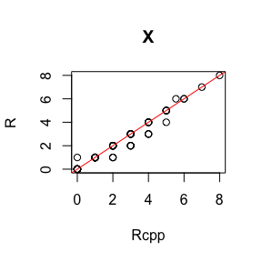

```r
set.seed(1)
N<-1e3
burn<-1e2
gibbc<-gibbsC(N,10)
gibbr<-gibbsR(N,10)
a<-ppoints(100)
Q11<-quantile(gibbc[(burn+1):N,1],a)
Q21<-quantile(gibbr[(burn+1):N,1],a)
qqplot(Q11,Q21,main="X",
       xlab = "Rcpp",ylab="R")
abline(0,1,col="red")
```

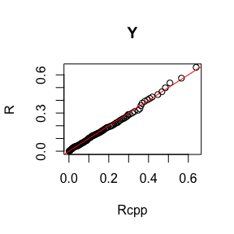

```r
Q12<-quantile(gibbc[(burn+1):N,2],a)
Q22<-quantile(gibbr[(burn+1):N,2],a)
qqplot(Q12,Q22,main="Y",
       xlab = "Rcpp",ylab="R")
abline(0,1,col="red")
```

对于X而言因为取值只有那几个所以可以看到仅有这几个点，但是有的点颜色更深，发现颜色更深的点基本在红线上，同时Y中点基本分布在红线上，可以认为两个抽样方法抽出的样本基本是一致的。

### 3

Compare the computation time of the two functions with the function “microbenchmark”.

```r
library(microbenchmark)
ts <- microbenchmark(gibbR=gibbsR(N,10),
                     gibbC=gibbsC(N,10))
  summary(ts)[,c(1,2,3,4,5,6,7)]
```

```
##    expr       min        lq      mean   median        uq       max
## 1 gibbR 55.937831 61.198920 66.792056 63.81197 66.364595 211.62903
## 2 gibbC  3.054718  3.079235  3.276795  3.09391  3.113621  18.17045
```

通过上述结果可以看出由于抽样结果基本一致，在时间上用R语言所需要的时间远远大于用Rcpp所需要的时间。

### 4

Comments your results.

通过上面的结果我们可以看到，通过Rcpp抽样得到的样本与单纯用R的结果基本是一致的但是速度更快。